# ggtree

## Some `ggtree` examples

See the full documentation here: https://yulab-smu.top/treedata-book/index.html

```r
library(ggplot2)
# this is for the read.iqtree
library(treeio)
library(ggtree)
# library(ggtreeExtra)
library(bactaxR)
library(tidyr)
library(stringr)
# getwd()
```

if the tree only has node labels and nothing else, we can read it with `read.tree()` from `ggtree`

```r
root <- "/run/media/mibu/ADATA_ext4/Umayor/Work/Blautia/genomes/rep_genomes/new_reprs"
f <- paste0(root, "/iqtree/repr_alrt.treefile_root")
file.exists(f)
```

```
[1] FALSE
```

```r
tree_alrt_root <- read.iqtree(paste0(f, ".nwk"))
tree_alrt_root@phylo$tip.label <- gsub('(GCF_[0-9]+.[0-9]{1,2}).*',
                         "\\1", tree_alrt_root@phylo$tip.label, perl=TRUE)
tree_alrt_root
```

```
'treedata' S4 object that stored information of
    '/run/media/mibu/ADATA_ext4/Umayor/Work/Blautia/genomes/rep_genomes/new_reprs/iqtree/repr_alrt.treefile_root.nwk'.

...@ phylo:
Phylogenetic tree with 36 tips and 35 internal nodes.

Tip labels:
  GCF_003463065.1, GCF_003011855.2, GCF_004123145.1, GCF_003435675.1, GCF_014287535.1, GCF_013300155.1, ...
Node labels:
  , 100/100, 100/100, 100/100, 100/100, 100/100, ...

Rooted; includes branch lengths.

with the following features available:
    'SH_aLRT',  'UFboot'.
```

For comparison with the next tree (before matching the tips and adding the names, etc., useful to make a visual check)

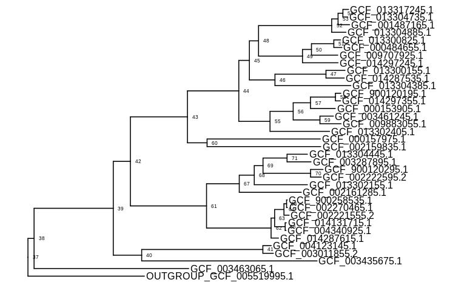

```r
ggtree(tree_alrt_root) + geom_tiplab() +  xlim(0, 1.15) +
  geom_nodelab(aes(label=node), size=2, hjust=-0.5)
```

Here we prepare the metadata, which will be used to annotate the tree

```r
meta_f <- paste0(root, '/representative_new.tsv')
file.exists(meta_f)
```

```
[1] TRUE
```

```r
meta_names <- read.csv(meta_f, sep = '\t')
meta_names$Assembly <- gsub('(GCF_[0-9]+.[0-9]{1,2}).*',
                         "\\1", meta_names$Assembly , perl=TRUE)
matches <- match(meta_names$Assembly, tree_alrt_root@phylo$tip.label)
meta_names <- meta_names[matches, ]
meta_names
```

|  | Assembly | Genome.name | Cluster_number |
| --- | --- | --- | --- |
| 34 | GCF_900120195.1 | Blautia sp. Strain Marseille-P3087T | 32 |
| 2 | GCF_003011855.2 | Blautia sp. SG-772 | 2 |
| 3 | GCF_004123145.1 | Blautia faecicola strain KGMB01111 | 3 |
| 5 | GCF_002159835.1 | Blautia sp. An249 | 5 |
| 22 | GCF_013304885.1 | Blautia schinkii strain MSK.15.25 | 20 |
| 1 | GCF_003287895.1 | Blautia sp. N6H1-15 strain KCTC 15426 | 1 |
| 7 | GCF_013304385.1 | Blautia glucerasea strain MSK.21.93 | 7 |
| 35 | GCF_013317245.1 | Blautia sp. MSK.20.85 | 33 |
| 8 | GCF_013304445.1 | Blautia hansenii strain MSK.15.26 | 8 |
| 32 | GCF_013300825.1 | Blautia wexlerae strain MSK.20.46 | 30 |

[output cut: 26 more lines]

**Important: When using the `%<+%` to add metadata to the tree, always pass a dataframe that has the tips’ labels in the first column. That first column will match with the column `label` already present in the tree (which is created by ggtree when we read the tree), and won’t be added to the tree data (see the next table)**

```r
# You can regulate the width of the tree lines using `size`
p <- ggtree(tree_alrt_root, color='#073D71', size=0.8) %<+% meta_names[, c("Assembly","Genome.name")]
p$data
```

| parent | node | branch.length | label | SH_aLRT | UFboot | isTip | x | y | branch | angle | Genome.name |
| --- | --- | --- | --- | --- | --- | --- | --- | --- | --- | --- | --- |
| 38 | 1 | 0.429950500 | GCF_003463065.1 | NA | NA | TRUE | 0.44699651 | 2.000000 | 0.232021262 | 20.00000 | Blautia sp. OF03-15BH |
| 41 | 2 | 0.029293971 | GCF_003011855.2 | NA | NA | TRUE | 0.68258322 | 4.000000 | 0.667936237 | 40.00000 | Blautia sp. SG-772 |
| 41 | 3 | 0.023277985 | GCF_004123145.1 | NA | NA | TRUE | 0.67656724 | 5.000000 | 0.664928244 | 50.00000 | Blautia faecicola strain KGMB01111 |
| 40 | 4 | 0.487730150 | GCF_003435675.1 | NA | NA | TRUE | 0.80400562 | 3.000000 | 0.560140547 | 30.00000 | Blautia sp. AM23-13AC |
| 47 | 5 | 0.050862677 | GCF_014287535.1 | NA | NA | TRUE | 0.87965916 | 27.000000 | 0.854227825 | 270.00000 | Blautia sp. BX17 |
| 47 | 6 | 0.053013183 | GCF_013300155.1 | NA | NA | TRUE | 0.88180967 | 28.000000 | 0.855303078 | 280.00000 | Blautia faecis strain MSK.18.51 |
| 46 | 7 | 0.211117920 | GCF_013304385.1 | NA | NA | TRUE | 0.89806570 | 26.000000 | 0.792506737 | 260.00000 | Blautia glucerasea strain MSK.21.93 |
| 49 | 8 | 0.098785860 | GCF_014297245.1 | NA | NA | TRUE | 0.86225957 | 29.000000 | 0.812866643 | 290.00000 | Blautia sp. M29 |
| 50 | 9 | 0.073261790 | GCF_009707925.1 | NA | NA | TRUE | 0.86169250 | 30.000000 | 0.825061602 | 300.00000 | Blautia luti DSM 14534 |
| 51 | 10 | 0.022437824 | GCF_000484655.1 | NA | NA | TRUE | 0.87305148 | 31.000000 | 0.861832563 | 310.00000 | Blautia wexlerae DSM 19850 |

[output cut: 61 more lines]

**Always check `p$data` if the annotation isn’t working as expected**

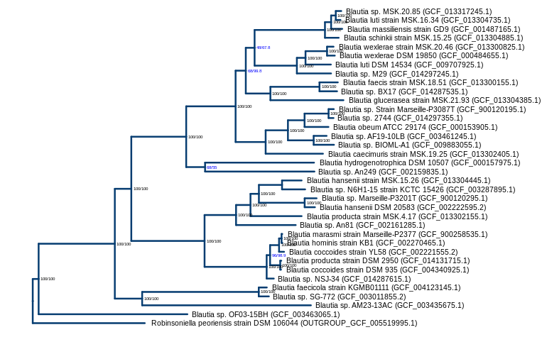

```r
p2 <- p + geom_tiplab(aes(label=paste0(Genome.name, " (", label, ")")),
                      size=2.5, hjust = -0.02) + xlim(0, 1.4) +
  geom_nodelab(aes(subset = (UFboot < 100),
                   label=paste0(UFboot,"/",SH_aLRT)),
               size=1.5,color='blue', hjust = -0.03) +
  geom_nodelab(aes(subset = (UFboot == 100),
                   label=paste0(UFboot,"/",SH_aLRT)),
               size=1.5, hjust = -0.03) #+ scaleClade(node=NULL,scale=2, vertical_only = TRUE)
p2
```

This is a more involved example using the clusters from `bactaxR` as metadata for annotation:

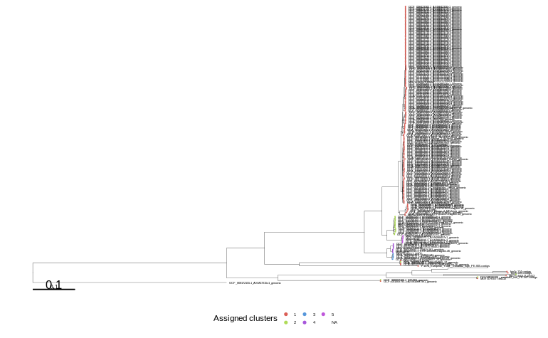

```r
colors_sns <- c('#db5f57', '#afdb57', '#5797db', '#a757db', '#bf57db', '#9D9D9D' )
root_trees <- "/run/media/mibu/LR-orico_mini/Recovery_ADATA/Umayor/Work/Akker/Orthofinder/Results_Nov12/Species_Tree/"
# edited tree species_tree_edited.nwk
f <- paste0(root_trees, 'SpeciesTree_rooted_node_labels.txt')
#
tree_all <- read.tree(f)
# ani <- read.ANI(file = "/run/media/mibu/LR-orico_mini/Recovery_ADATA/Umayor/Work/Akker/Verrucomicrobia/FastANI/bactaxR_related/g_akk_prokka_fna.tsv")
# dend_g_akk <- ANI.dendrogram(bactaxRObject = ani, ANI_threshold = 95, label_size = 0.1)
# size is important for the width of the tree lines
p <- ggtree(tree_all, size = 0.1)  %<+%  dend_g_akk$cluster_assignments[c('Genome', 'Cluster')] + xlim(0, 1.15)
p +  geom_tiplab(size= 1, offset = 0.001) +
geom_tippoint(aes(color = factor(Cluster)), size=0.01) +
  # Position and size of the scale
   geom_treescale(x= 0, y= -4, fontsize = 2) +
  scale_color_manual(values=colors_sns) + geom_treescale(x= 0, y=-4, fontsize = 4) +
guides(color = guide_legend(override.aes = list(size = 1), title = 'Assigned clusters')) +
  theme(legend.position = 'bottom', legend.key.size = unit(8, "point"),
        legend.text = element_text(size = 4), legend.title = element_text(size=8))
```

This tree is too big for this format, but when saved as svg with `ggsave` it gets displayed properly.

### Modify tip labels

Here, we use a table with information about the `GTDB-tk` species classification and add it to the tree:

```r
qc_path <- '/run/media/mibu/LR-orico_mini/Recovery_ADATA/Umayor/Work/Akker/Verrucomicrobia/QC/'
merged_akk <- read.table(paste0(qc_path, 'merged_akk_hand_edited.tsv'), header=TRUE, sep='\t')
# Create a new column representing the gtdb species classification
merged_akk$'GTDB_specie' <- merged_akk$classification %>% str_extract('(s_.+)')
head(merged_akk)
```

|  | Genome | Completeness | Contamination | classification | classification_method | sum_len | N50 | X16S.ribosomal.RNA...1400.nt | Total_tRNAs | host | NCBI_organism_name | NCBI_infraspecific_name | relation_to_type_material | type_of_sample | GTDB_specie |
| --- | --- | --- | --- | --- | --- | --- | --- | --- | --- | --- | --- | --- | --- | --- | --- |
| 1 | DGYMR06203__metabat2_low_PE.047.contigs | 91.12 | 0.00 | d__Bacteria;p__Verrucomicrobiota;c__Verrucomicrobiae;o__Verrucomicrobiales;f__Akkermansiaceae;g__Akkermansia;s__Akkermansia sp900548895 | taxonomic classification defined by topology and ANI | 2417897 | 26278 | NA | 44 | gallus gallus |  |  |  | metagenome | s__Akkermansia sp900548895 |
| 2 | F157a_European_Toad__metabat2_high_PE.005.contigs | 89.32 | 2.30 | d__Bacteria;p__Verrucomicrobiota;c__Verrucomicrobiae;o__Verrucomicrobiales;f__Akkermansiaceae;g__Akkermansia;s__ | taxonomic classification defined by topology and ANI | 2029501 | 8457 | NA | 40 | bufo bufo |  |  |  | metagenome | s__ |
| 3 | GCA_000436395.1_MGS154_genomic | 95.07 | 0.00 | d__Bacteria;p__Verrucomicrobiota;c__Verrucomicrobiae;o__Verrucomicrobiales;f__Akkermansiaceae;g__Akkermansia;s__Akkermansia muciniphila | taxonomic classification defined by topology and ANI | 2721828 | 74342 | NA | 46 | homo sapiens |  |  |  | metagenome | s__Akkermansia muciniphila |
| 4 | GCA_000437075.1_MGS344_genomic | 97.25 | 1.36 | d__Bacteria;p__Verrucomicrobiota;c__Verrucomicrobiae;o__Verrucomicrobiales;f__Akkermansiaceae;g__Akkermansia;s__Akkermansia muciniphila_B | taxonomic classification defined by topology and ANI | 3024253 | 170254 | NA | 50 | homo sapiens |  |  |  | metagenome | s__Akkermansia muciniphila_B |
| 5 | GCA_001917295.1_ASM191729v1_genomic | 97.28 | 0.00 | d__Bacteria;p__Verrucomicrobiota;c__Verrucomicrobiae;o__Verrucomicrobiales;f__Akkermansiaceae;g__Akkermansia;s__Akkermansia muciniphila | taxonomic classification defined by topology and ANI | 2966498 | 183307 | NA | 47 | homo sapiens |  |  |  | metagenome | s__Akkermansia muciniphila |
| 6 | GCA_002362435.1_ASM236243v1_genomic | 95.87 | 0.68 | d__Bacteria;p__Verrucomicrobiota;c__Verrucomicrobiae;o__Verrucomicrobiales;f__Akkermansiaceae;g__Akkermansia;s__Akkermansia muciniphila_A | taxonomic classification defined by topology and ANI | 2450463 | 103020 | NA | 42 | rat |  |  |  | metagenome | s__Akkermansia muciniphila_A |

```r
p <- ggtree(tree_all, size = 0.1)  %<+%  dend_g_akk$cluster_assignments[c('Genome', 'Cluster')] %<+%
  merged_akk[c('Genome', 'GTDB_specie')]
head(p$data)
```

| parent | node | branch.length | label | isTip | x | y | branch | angle | Cluster | GTDB_specie |
| --- | --- | --- | --- | --- | --- | --- | --- | --- | --- | --- |
| 203 | 1 | 0.459136000 | GCF_000172155.1_ASM17215v1_genomic | TRUE | 0.4591360 | 1 | 0.2295680 | 1.782178 | NA | NA |
| 208 | 2 | 0.000000005 | GCA_905197035.1_ERR2013654-mag-bin.36_genomic | TRUE | 0.8717211 | 14 | 0.8717211 | 24.950495 | 1 | s__Akkermansia sp900545155 |
| 208 | 3 | 0.000035371 | GCA_900545155.1_UMGS750_genomic | TRUE | 0.8717565 | 15 | 0.8717388 | 26.732673 | 1 | s__Akkermansia sp900545155 |
| 209 | 4 | 0.000006448 | GCA_900765745.1_SRS294966_17_genomic | TRUE | 0.8717396 | 16 | 0.8717364 | 28.514851 | 2 | s__Akkermansia sp900545155 |
| 209 | 5 | 0.000012941 | MGYG-HGUT-02584 | TRUE | 0.8717461 | 17 | 0.8717397 | 30.297030 | 1 | s__Akkermansia sp900545155 |
| 206 | 6 | 0.281147000 | F157a_European_Toad__metabat2_high_PE.005.contigs | TRUE | 0.9132037 | 13 | 0.7726302 | 23.168317 | 1 | s__ |

Then, we can add this information to the tip labels, separated by `|`:

```r
p +  geom_tiplab(aes(label=paste0(GTDB_specie, " | ", cluster, " | ", label)), size= 1) + ...
```

(See previous table to understand the name of the variables used)